# 《R语言实战》学习笔记-4 基本数据管理

By JunHui Li

2018 年 12 月 27 日

## 主要内容

- 操纵日期和缺失值
- 熟悉数据类型的转换
- 变量的创建和重编码
- 数据集的排序，合并与取子集
- 选入和丢弃变量

## 4.1 一个示例

当前工作的研究主题之一是男性和女性在领导各自企业方式上的不同。典型的问题如下。

- 处于管理岗位的男性和女性在听从上级的程度上是否有所不同？
- 这种情况是否依国家的不同而有所不同，或者说这些由性别导致的不同是否普遍存在

结果数据可能类似于表4-1。各行数据代表了某个经理人的上司对他的评分。

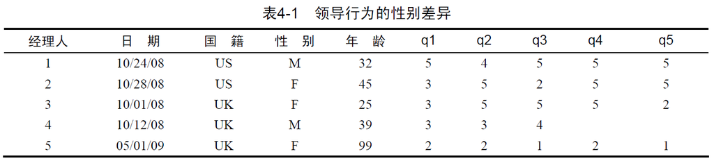

创建 leadership 数据框：

```r
manager <- c(1, 2, 3, 4, 5)
date <- c("10/24/08", "10/28/08", "10/1/08", "10/12/08", "5/1/09")
gender <- c("M", "F", "F", "M", "F")
age <- c(32, 45, 25, 39, 99)
q1 <- c(5, 3, 3, 3, 2)
q2 <- c(4, 5, 5, 3, 2)
q3 <- c(5, 2, 5, 4, 1)
q4 <- c(5, 5, 5, NA, 2)
q5 <- c(5, 5, 2, NA, 1)
leadership <- data.frame(manager, date, gender, age, q1, q2, q3, q4, q5, stringsAsFactors = FALSE)
```

```r
leadership
```

```
##   manager     date gender age q1 q2 q3 q4 q5
## 1       1 10/24/08      M  32  5  4  5  5  5
## 2       2 10/28/08      F  45  3  5  2  5  5
## 3       3  10/1/08      F  25  3  5  5  5  2
## 4       4 10/12/08      M  39  3  3  4 NA NA
## 5       5   5/1/09      F  99  2  2  1  2  1
```

## 4.2 创建新变量

表 4-2 列出了 R 中的算术运算符。算术运算符可用于构造公式（formula）。

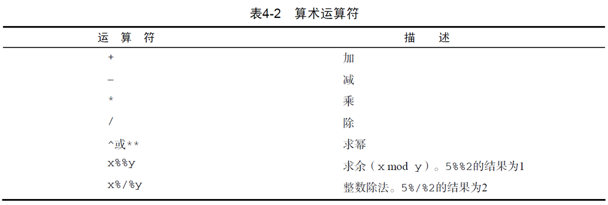

三种方式，新建数据框：

```r
mydata <- data.frame(x1 = c(2, 2, 6, 4), x2 = c(3, 4, 2, 8))
```

方法一：

```r
mydata$sumx <- mydata$x1 + mydata$x2
mydata$meanx <- (mydata$x1 + mydata$x2)/2
```

方法二：

```r
attach(mydata)
mydata$sumx <- x1 + x2
mydata$meanx <- (x1 + x2)/2
detach(mydata)
```

方法三：

```r
mydata <- transform(mydata, sumx = x1 + x2, meanx = (x1 + x2)/2)
```

作者推荐使用第三种方式，即 **transform()** 函数示例。这种方式简化了按需创建新变量并将其保存到数据框中的过程。

## 4.3 变量的重编码

重编码涉及根据同一个变量和/或其他变量的现有值创建新值的过程。举例来说，你可能想：

- 将一个连续型变量修改为一组类别值；
- 将误编码的值替换为正确值；
- 基于一组分数线创建一个表示及格/不及格的变量。

要重编码数据，可以使用 R 中的一个或多个逻辑运算符（表 4-3）。逻辑运算符表达式可返回TRUE或FALSE。

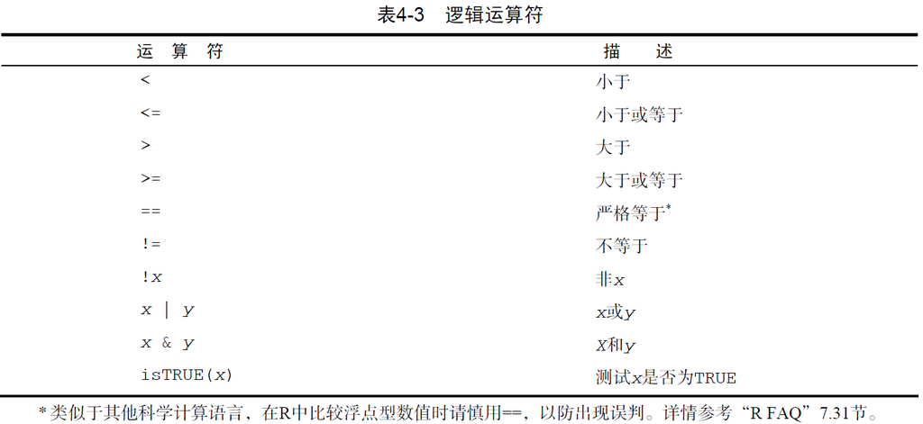

假设你希望将 leadership 数据集中经理人的连续型年龄变量 age 重编码为类别型变量 agecat（Young、 Middle Aged、Elder）。首先，必须将 99 岁的年龄值重编码为缺失值，使用的代码为：

```r
leadership$age[leadership$age == 99] <- NA
```

在指定好年龄中的缺失值后，使用以下代码创建 agecat 变量：

```r
leadership$agecat[leadership$age > 75] <- "Elder"
leadership$agecat[leadership$age > 45 & leadership$age <= 75] <- "Middle Aged"
leadership$agecat[leadership$age <= 45] <- "Young"
```

```r
leadership <- within(leadership, {
    agecat <- NA
    agecat[age > 75] <- "Elder"
    agecat[age >= 55 & age <= 75] <- "Middle Aged"
    agecat[age < 55] <- "Young"
})
```

```r
leadership
```

```
##   manager     date gender age q1 q2 q3 q4 q5 agecat
## 1       1 10/24/08      M  32  5  4  5  5  5  Young
## 2       2 10/28/08      F  45  3  5  2  5  5  Young
## 3       3  10/1/08      F  25  3  5  5  5  2  Young
## 4       4 10/12/08      M  39  3  3  4 NA NA  Young
## 5       5   5/1/09      F  NA  2  2  1  2  1   <NA>
```

## 4.4 变量的重命名

1. 使用交互式编辑器直接修改

```r
fix(leadership)
```

2. 使用 reshape 包

```r
library(reshape)
rename(leadership, c(manager = "managerID", date = "testDate"))
```

```
##   managerID testDate gender age q1 q2 q3 q4 q5 agecat
## 1         1 10/24/08      M  32  5  4  5  5  5  Young
## 2         2 10/28/08      F  45  3  5  2  5  5  Young
## 3         3  10/1/08      F  25  3  5  5  5  2  Young
## 4         4 10/12/08      M  39  3  3  4 NA NA  Young
## 5         5   5/1/09      F  NA  2  2  1  2  1   <NA>
```

3. 使用 **names()** 函数

```r
names(leadership)[2] <- "testDate"
```

类似的，修改第 5~9 个变量名称

```r
names(leadership)[5:9] <- c("item1", "item2", "item3", "item4", "item5")
```

修改后 leadship 数据框如下：

```r
leadership
```

```
##   manager testDate gender age item1 item2 item3 item4 item5 agecat
## 1       1 10/24/08      M  32     5     4     5     5     5  Young
## 2       2 10/28/08      F  45     3     5     2     5     5  Young
## 3       3  10/1/08      F  25     3     5     5     5     2  Young
## 4       4 10/12/08      M  39     3     3     4    NA    NA  Young
## 5       5   5/1/09      F  NA     2     2     1     2     1   <NA>
```

## 4.5 缺失值

缺失值以符号 NA（Not Available，不可用）表示

不可能出现的值（例如，被 0 除的结果），通过符号 NaN（Not a Number，非数值）来表示。

函数 **is.na()** 检测缺失值是否存在，如：

```r
y <- c(1, 2, 3, NA)
is.na(y)
```

```
## [1] FALSE FALSE FALSE  TRUE
```

即返回一个相同大小的对象，如果某个元素是缺失值，相应的位置将被改写为TRUE，不是缺失值的位置则为FALSE

```r
is.na(leadership[, 6:10])
```

```
##   item2 item3 item4 item5 agecat
## 1 FALSE FALSE FALSE FALSE  FALSE
## 2 FALSE FALSE FALSE FALSE  FALSE
## 3 FALSE FALSE FALSE FALSE  FALSE
## 4 FALSE FALSE  TRUE  TRUE  FALSE
## 5 FALSE FALSE FALSE FALSE   TRUE
```

注：缺失值不可比较，例如，逻辑测试 myvar == NA 的结果永远不会为TRUE

注：含有缺失值的算术表达式和函数的计算结果也是缺失值，在进一步分析之前应该删除，使用 **na.rm=TRUE**，如：

```r
x <- c(1, 2, NA, 3)
y <- sum(x, na.rm = T)
```

可以通过函数 **na.omit()** 移除所有含有缺失值的观测，**na.omit()** 可以删除所有含有缺失数据的行，如

```r
newdata <- na.omit(leadership)
newdata
```

```
##   manager testDate gender age item1 item2 item3 item4 item5 agecat
## 1       1 10/24/08      M  32     5     4     5     5     5  Young
## 2       2 10/28/08      F  45     3     5     2     5     5  Young
## 3       3  10/1/08      F  25     3     5     5     5     2  Young
```

## 4.6 日期值

日期值通常以字符串的形式输入到R中，然后转化为以数值形式存储的日期变量。函数 **as.Date()** 用于执行这种转化。其语法为 **as.Date(x, “input_format”)**，其中 x 是字符型数据，input_format 则给出了用于读入日期的适当格式。常见日期格式如下：

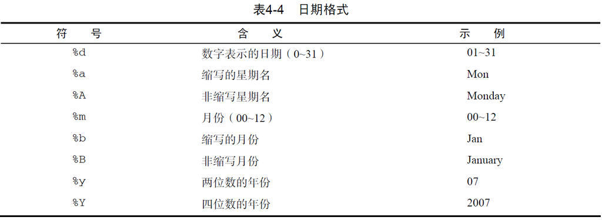

日期值的默认输入格式为 **yyyy-mm-dd**。下列语句将默认格式的字符型数据转换为了对应日期：

```r
mydates <- as.Date(c("2007-06-22", "2004-02-13"))
```

下列语句使用 **mm/dd/yyyy** 格式读取数据：

```r
strDates <- c("01/05/1965", "08/16/1975")
dates <- as.Date(strDates, "%m/%d/%Y")
```

用于处理时间戳数据的两个函数：

- **Sys.Date()** 返回当天的日期
- **date()** 返回当前的日期和时间

使用函数 **format(x, format=“output_format”)** 输出指定格式的日期值，并且提取日期值中的某些部分：

```r
today <- Sys.Date()
format(today, format = "%B %d %Y")
```

```
## [1] "十二月 29 2018"
```

```r
format(today, format = "%A")
```

```
## [1] "星期六"
```

```r
startdate <- as.Date("2004-02-13")
enddate <- as.Date("2009-06-22")
(days <- enddate - startdate)
```

```
## Time difference of 1956 days
```

使用函数 **difftime()** 来计算时间间隔，并以星期、天、时、分、秒来表示，例如：

```r
today <- Sys.Date()
dob <- as.Date("1956-10-10")
difftime(today, dob, units = "weeks")
```

```
## Time difference of 3246.429 weeks
```

## 4.7 类型转换

类型转换函数：

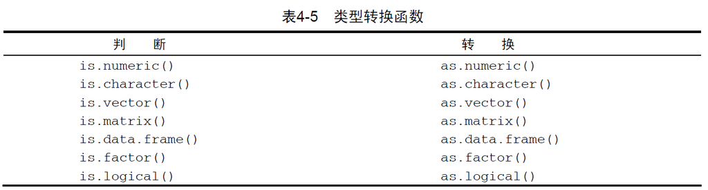

转换数据类型

```r
a <- c(1, 2, 3)
a
```

```
## [1] 1 2 3
```

```r
is.numeric(a)
```

```
## [1] TRUE
```

```r
is.vector(a)
```

```
## [1] TRUE
```

```r
a <- as.character(a)
a
```

```
## [1] "1" "2" "3"
```

```r
is.numeric(a)
```

```
## [1] FALSE
```

```r
is.vector(a)
```

```
## [1] TRUE
```

```r
is.character(a)
```

```
## [1] TRUE
```

## 4.8 数据排序

在R中，可以使用 **order()** 函数对一个数据框进行排序。默认的排序顺序是升序。在排序变量的前边加一个减号即可得到降序的排序结果。以下示例使用 leadership 演示了数据框的排序：

```r
attach(leadership)
newdata <- leadership[order(age), ]
newdata
```

```
##   manager testDate gender age item1 item2 item3 item4 item5 agecat
## 3       3  10/1/08      F  25     3     5     5     5     2  Young
## 1       1 10/24/08      M  32     5     4     5     5     5  Young
## 4       4 10/12/08      M  39     3     3     4    NA    NA  Young
## 2       2 10/28/08      F  45     3     5     2     5     5  Young
## 5       5   5/1/09      F  NA     2     2     1     2     1   <NA>
```

```r
detach(leadership)
```

创建了一个新的数据集，各行依经理人的年龄升序排序。

```r
attach(leadership)
newdata <- leadership[order(gender, -age), ]
newdata
```

[output not shown]

```r
detach(leadership)
```

创建了一个新的数据集，将各行依女性到男性、同样性别中按年龄降序排序。

## 4.9 数据集的合并

### 4.9.1 添加列

要横向合并两个数据框（数据集），使用 **merge()** 函数。在多数情况下，两个数据框是通过一个或多个共有变量进行联结的（即一种内联结，inner join）。例如：

total <- merge(dataframeA, dataframeB, by = “ID”)

将dataframeA和dataframeB按照ID进行了合并。类似地，

total <- merge(dataframeA, dataframeB, by = c(“ID”, “Country”))

将两个数据框按照 ID 和 Country 进行了合并。类似的横向联结通常用于向数据框中添加变量。

注：如果要直接横向合并两个矩阵或数据框，并且不需要指定一个公共索引，那么可以直接使用 **cbind()** 函数，这个函数将横向合并对象 A 和对象 B。为了让它正常工作，每个对象必须拥有相同的行数，且要以相同顺序排序。

total <- cbind(A, B)

### 4.9.2 添加行

要纵向合并两个数据框（数据集），使用 **rbind()** 函数：

total <- rbind(dataframeA, dataframeB)

两个数据框必须拥有相同的变量，不过它们的顺序不必一定相同。如果 dataframeA 中拥有 dataframeB 中没有的变量，请在合并它们之前做以下某种处理：

- 删除 dataframeA 中的多余变量；
- 在 dataframeB 中创建追加的变量并将其值设为 NA（缺失）。

纵向联结通常用于向数据框中添加观测。

## 4.10 数据集取子集

### 4.10.1 选入（保留）变量

数据框中的元素可以通过 dataframe[row indices, column indices] 来获取，如：

- newdata <- leadership[, c(6:10)]

- myvars <- c(“q1”,“q2”,“q3”,“q4”,“q5”)
- newdata <- leadership[myvars]

或

- myvars <- paste(“q”, 1:5, sep = “”)
- newdata <- leadership[myvars]

### 4.10.2 剔除（丢弃）变量

从 leadership 数据框中剔除变量 q3 和 q4：

方法一（只知道变量名称）：

- myvars <- names(leadership) %in% c(“q3”, “q4”)
- newdata <- leadership[!myvars]

方法二（知道 q3 和 q4 是第 7 个和第 8 个变量）：

- newdata <- leadership[c(-7, -8)]

方法三（将 q3 和 q4 两列设为未定义（NULL）。注意，NULL 与 NA（表示缺失）是不同的）：

- leadership$q3 <- leadership$q4 <- NULL

### 4.10.3 选入观测

示例如下：

- newdata <- leadership[1:3, ]
- newdata <- leadership[which(leadership$gender == “M” & leadership$age > 30), ]

限定时间范围：

- leadership$date <- as.Date(leadership$date, “%m/%d/%y”)
- startdate <- as.Date(“2009-01-01”)
- enddate <- as.Date(“2009-10-31”)
- newdata <- leadership[leadership$date >= startdate & leadership$date <= enddate, ]

### 4.10.4 subset() 函数

示例：

1. newdata <- subset(leadership, age >= 35 | age < 24, select = c(q1, q2, q3, q4))

选择了所有 age 值大于等于 35 或 age 值小于 24 的行，保留了变量 q1 到 q4

2. newdata <- subset(leadership, gender == “M” & age > 25, select = gender:q4)

选择了所有 25 岁以上的男性，并保留了变量 gender 到 q4（gender、q4 和其间所有列）。

### 4.10.5 随机抽样

**sample()** 函数能够让你从数据集中（有放回或无放回地）抽取大小为 n 的一个随机样本。

可以使用以下语句从 leadership 数据集中随机抽取一个大小为3的样本：

- mysample <- leadership[sample(1:nrow(leadership), 3, replace = FALSE), ]

**sample()** 函数中的第一个参数是一个由要从中抽样的元素组成的向量。在这里，这个向量是 1 到数据框中观测的数量，第二个参数是要抽取的元素数量，第三个参数表示无放回抽样。**sample()** 函数会返回随机抽样得到的元素，之后即可用于选择数据框中的行。

## 4.11 使用SQL 语句操作数据框

略